# Project1-Markdown

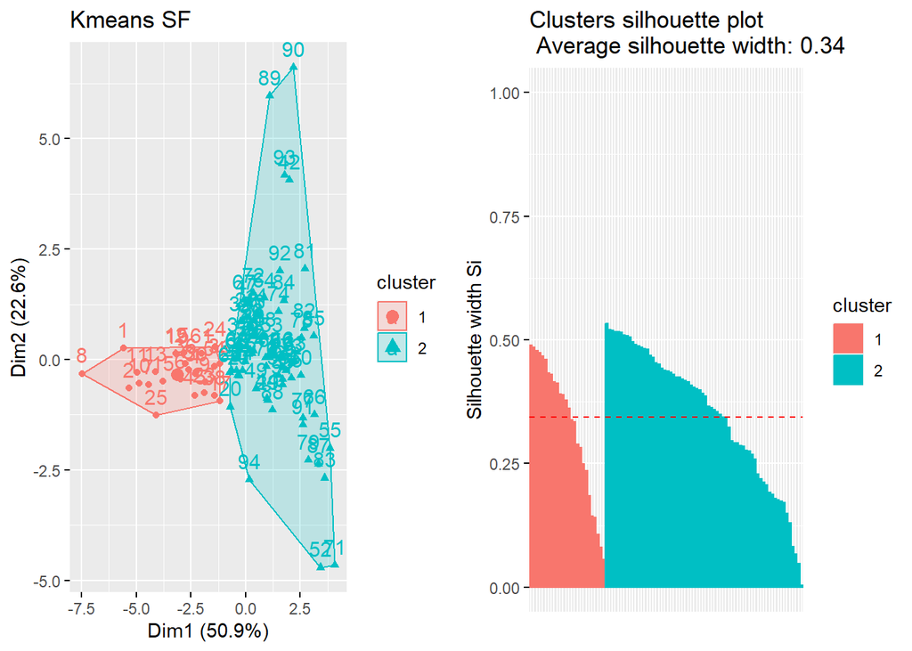

```
##   cluster size ave.sil.width
## 1       1   26          0.33
## 2       2   68          0.35
```

```r
grid.arrange(
  fviz_cluster(SF_clust,
               data = scaled_SF,
               elipse.type = 'convex',
               main='Kmeans SF'),
  fviz_silhouette(SF_clust),
  ncol=2)
```

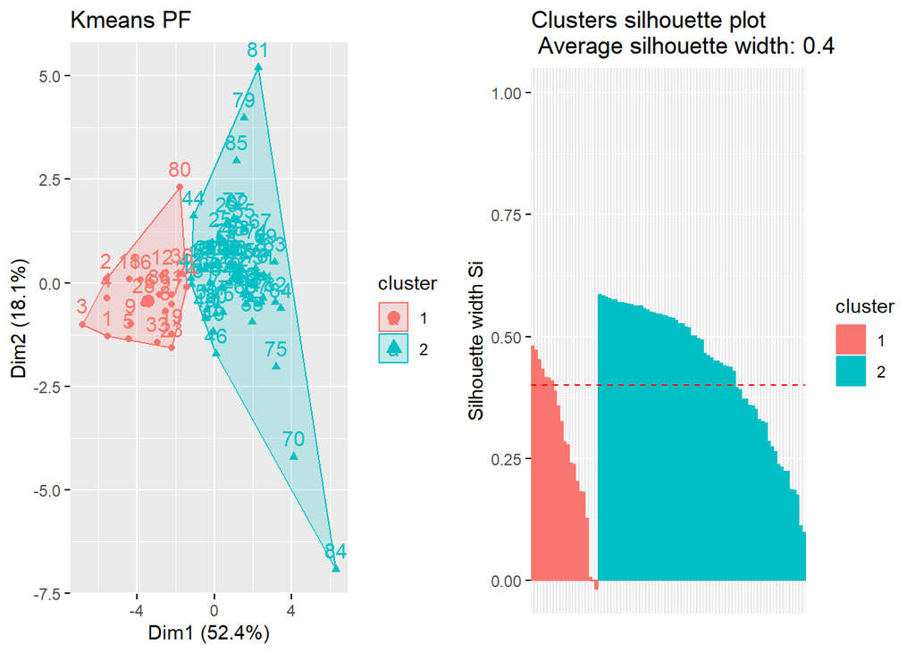

```
##   cluster size ave.sil.width
## 1       1   21          0.28
## 2       2   65          0.44
```

```r
grid.arrange(
  fviz_cluster(PF_clust,
               data = scaled_PF,
               elipse.type = 'convex',
               main='Kmeans PF'),
  fviz_silhouette(PF_clust),
  ncol=2)
```

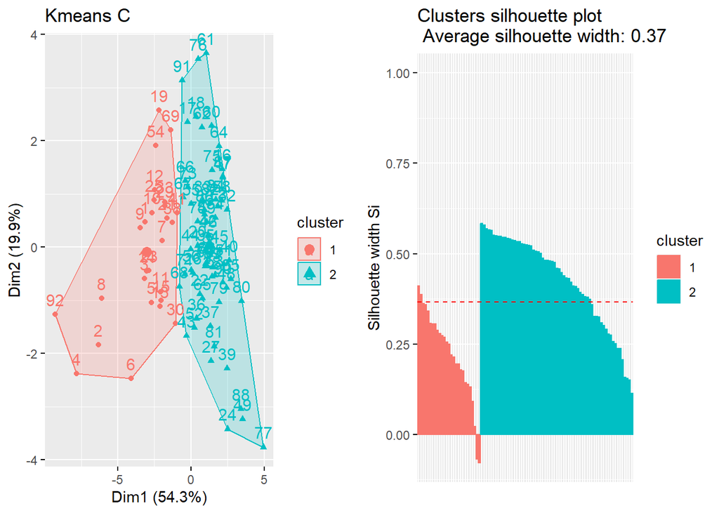

```
##   cluster size ave.sil.width
## 1       1   27          0.22
## 2       2   65          0.43
```

```r
grid.arrange(
  fviz_cluster(C_clust,
               data = scaled_C,
               elipse.type = 'convex',
               main='Kmeans C'),
  fviz_silhouette(C_clust),
  ncol=2)
```

### PAM clustering.

```r
PG_clust_pam <- eclust(scaled_PG, FUNcluster = 'pam', k=2, graph=F)

SG_clust_pam <- eclust(scaled_SG, FUNcluster = 'pam', k=2, graph=F)

SF_clust_pam <- eclust(scaled_SF, FUNcluster = 'pam', k=2, graph=F)

PF_clust_pam <- eclust(scaled_PF, FUNcluster = 'pam', k=2, graph=F)

C_clust_pam <- eclust(scaled_C, FUNcluster = 'pam', k=2, graph=F)
```

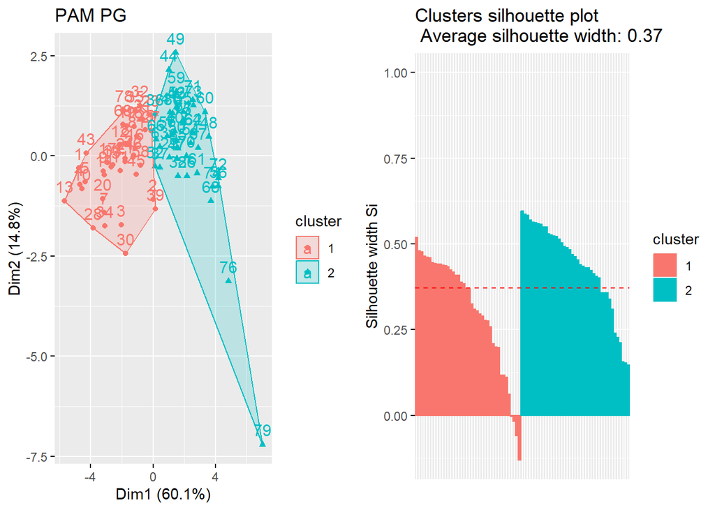

```
##   cluster size ave.sil.width
## 1       1   40          0.31
## 2       2   41          0.44
```

```r
grid.arrange(
  fviz_cluster(PG_clust_pam,
               data = scaled_PG,
               elipse.type = 'convex',
               main='PAM PG'),
  fviz_silhouette(PG_clust_pam),
  ncol=2)
```

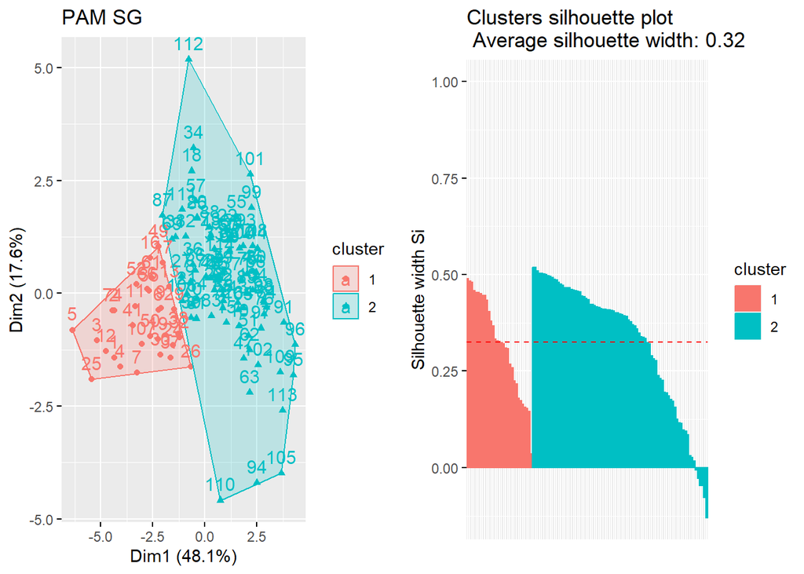

```
##   cluster size ave.sil.width
## 1       1   31          0.32
## 2       2   83          0.33
```

```r
grid.arrange(
  fviz_cluster(SG_clust_pam,
               data = scaled_SG,
               elipse.type = 'convex',
               main='PAM SG'),
  fviz_silhouette(SG_clust_pam),
  ncol=2)
```

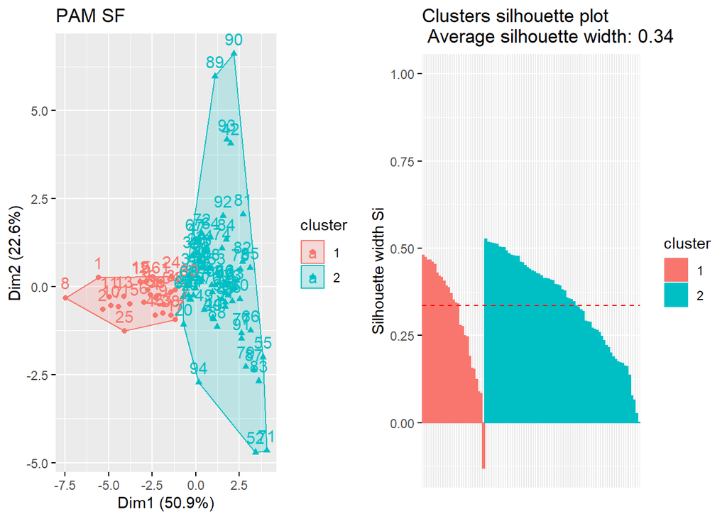

```
##   cluster size ave.sil.width
## 1       1   27          0.31
## 2       2   67          0.35
```

```r
grid.arrange(
  fviz_cluster(SF_clust_pam,
               data = scaled_SF,
               elipse.type = 'convex',
               main='PAM SF'),
  fviz_silhouette(SF_clust_pam),
  ncol=2)
```

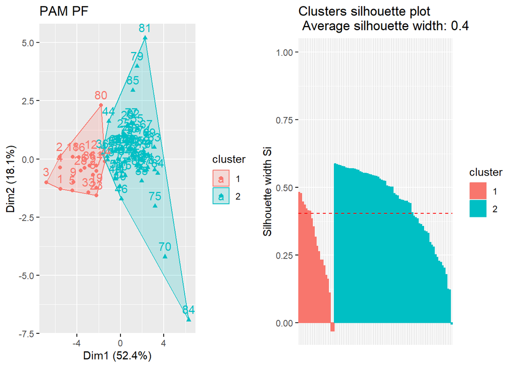

```
##   cluster size ave.sil.width
## 1       1   20          0.29
## 2       2   66          0.44
```

```r
grid.arrange(
  fviz_cluster(PF_clust_pam,
               data = scaled_PF,
               elipse.type = 'convex',
               main='PAM PF'),
  fviz_silhouette(PF_clust_pam),
  ncol=2)
```

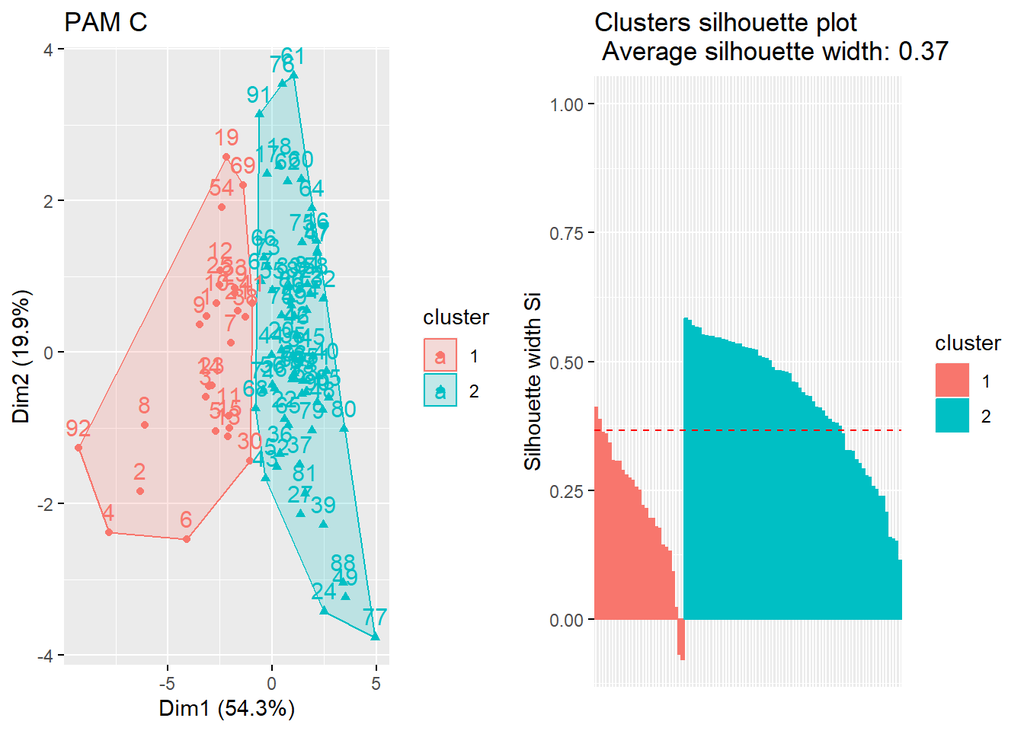

```
##   cluster size ave.sil.width
## 1       1   27          0.22
## 2       2   65          0.43
```

```r
grid.arrange(
  fviz_cluster(C_clust_pam,
               data = scaled_C,
               elipse.type = 'convex',
               main='PAM C'),
  fviz_silhouette(C_clust_pam),
  ncol=2)
```

### Which method is better for further analysis?

To further interpret the dependencies and relationships within the clusters one method should be chosen. In order to decide whether K-means or PAM clustering works better in this case, the weighted average will be calculated, treating the number of players in each group, based on their court role (number of observations), as weights for the average silhouette value within such group.

```r
kmeans_sils = c(PG_clust$silinfo$avg.width, SG_clust$silinfo$avg.width, SF_clust$silinfo$avg.width, PF_clust$silinfo$avg.width, C_clust$silinfo$avg.width)

kmeans_weigths = c(length(stats_PG[,1]), length(stats_SG[,1]),length(stats_SF[,1]), length(stats_PF[,1]), length(stats_C[,1]))

weighted.mean(kmeans_sils, kmeans_weigths)
```

```
## [1] 0.355592
```

```r
pam_sils = c(PG_clust_pam$silinfo$avg.width, SG_clust_pam$silinfo$avg.width, SF_clust_pam$silinfo$avg.width, PF_clust_pam$silinfo$avg.width, C_clust_pam$silinfo$avg.width)

pam_weigths = c(length(stats_PG[,1]), length(stats_SG[,1]),length(stats_SF[,1]), length(stats_PF[,1]), length(stats_C[,1]))

weighted.mean(pam_sils, pam_weigths)
```

```
## [1] 0.357822
```

Average width for the whole data set based on court role is minimally higher for the PAM clustering method.

## Hierarchical clustering.

### Optimal number of clusters.

We consider two types of hierarchical clustering, divisive (top-down) and agglomerative (bottom-up). The divisive approach means that division starts from each point being in the same cluster, dividing them then into smaller pairs, with the agglomerative approach being the opposite of the aforementioned.

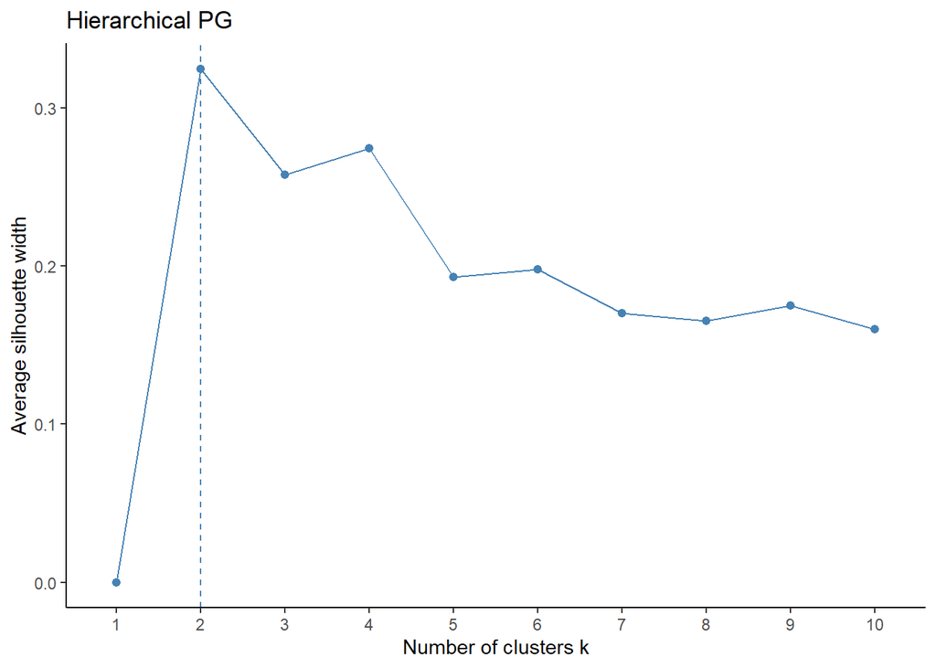

```r
fviz_nbclust(scaled_PG, FUNcluster = hcut, method = 'silhouette') + theme_classic() + ggtitle('Hierarchical PG')
```

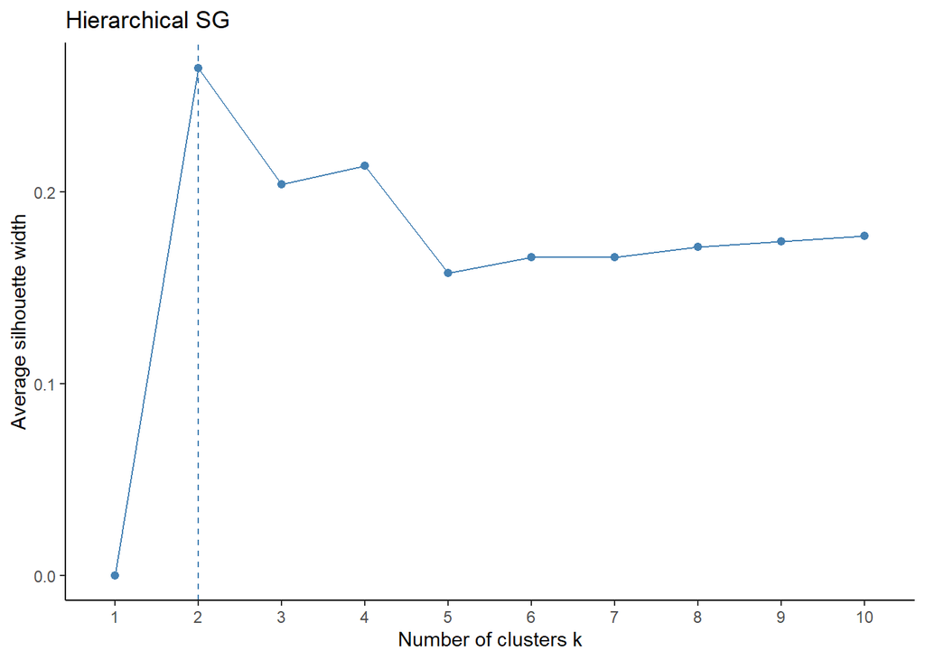

```r
fviz_nbclust(scaled_SG, FUNcluster = hcut, method = 'silhouette') + theme_classic() + ggtitle('Hierarchical SG')
```

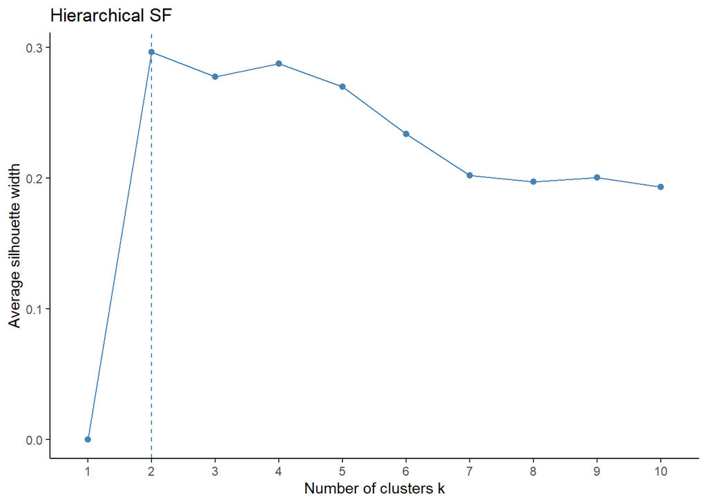

```r
fviz_nbclust(scaled_SF, FUNcluster = hcut, method = 'silhouette') + theme_classic() + ggtitle('Hierarchical SF')
```

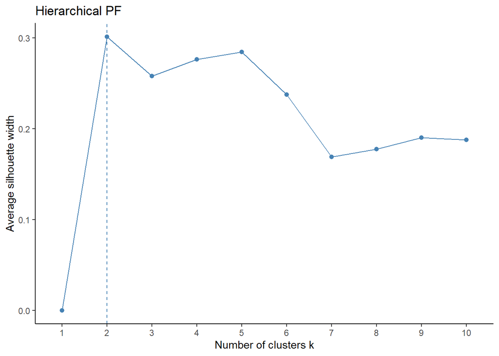

```r
fviz_nbclust(scaled_PF, FUNcluster = hcut, method = 'silhouette') + theme_classic() + ggtitle('Hierarchical PF')
```

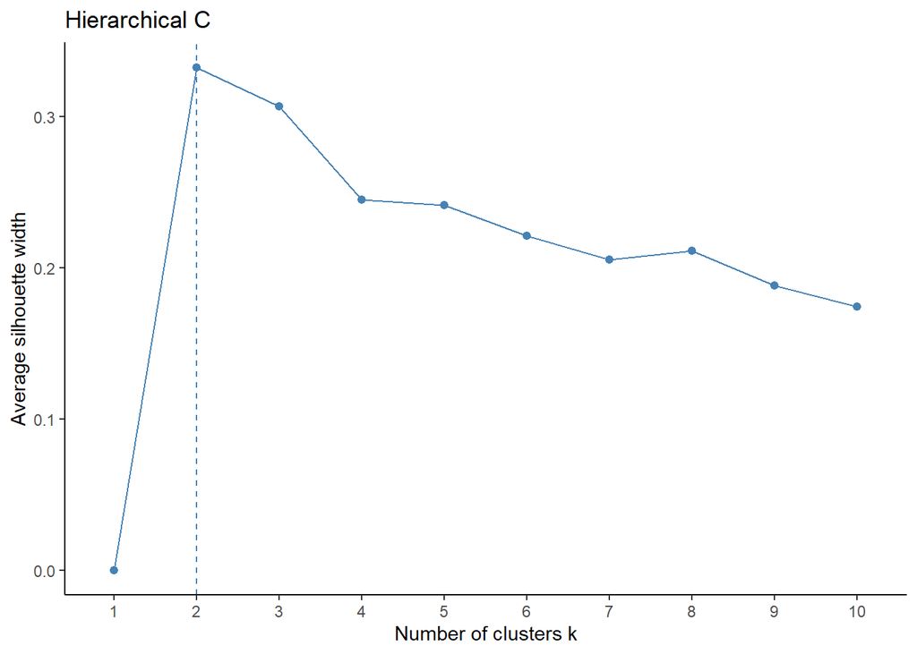

```r
fviz_nbclust(scaled_C, FUNcluster = hcut, method = 'silhouette') + theme_classic() + ggtitle('Hierarchical C')
```

For each on-court position, as in the partition clustering, the best number of clusters is 2. The analysis with the both top-down and bottom-up approach will be conducted, taking various linkage types into consideration. The best method will be selected based on the silhouette width, as in the case of partition clustering and the values will be compared to select the result, on which the final analysis of clusters contents will be conducted.

```r
# setting names of rows to Players Names to better visualize dendrograms

rownames(scaled_PG) = stats_PG$Player.Name
rownames(scaled_SG) = stats_SG$Player.Name
rownames(scaled_SF) = stats_SF$Player.Name
rownames(scaled_PF) = stats_PF$Player.Name
rownames(scaled_C) = stats_C$Player.Name
```